# EDS Processing Part 2: Signal Extraction from the (denoised) Datacube

**Author:** Lukas Grünewald  
**Last edited:** 25.10.23  
**HyperSpy Version:** 1.7.5

### Purpose:

Qualitative elemental maps (background-corrected peak net-intensities) are extracted from the (denoised) EDS dataset.

### Usage:

Copy this notebook in the same folder containing the **Part1-MSA** notebook and the .bcf file.  
Run the accompanying **Part1-MSA** notebook beforehand to perform pre-processing and, e.g., PCA denoising.

## Preparation

```python
# Use watermark package to document package versions and hardware info
%load_ext watermark
# We use the widget backend for the explained notebooks
# Use qt for actual use with traitsui elements
%matplotlib widget
#%matplotlib qt

# Main packages
import hyperspy.api as hs
import numpy as np
import matplotlib.pyplot as plt
import matplotlib

# Extras
from tifffile import imwrite
from skimage.transform import rescale # for upscaling images
import os
from pathlib import Path # Deal with Windows/Unix path issues
```

```python
%watermark -i -v -u -m --iversions
```

```
Last updated: 2023-10-25T11:24:42.700834+02:00

Python implementation: CPython
Python version       : 3.10.13
IPython version      : 8.16.1

Compiler    : GCC 11.2.0
OS          : Linux
Release     : 6.5.6-100.fc37.x86_64
Machine     : x86_64
Processor   : x86_64
CPU cores   : 8
Architecture: 64bit

numpy     : 1.24.4
matplotlib: 3.8.0
hyperspy  : 1.7.5
```

```python
path = Path(os.getcwd())# Path to EDS file, recommended to be in same folder as the notebooks
```

```python
# Specify minimum image size in pixels of png overview images
# For example, a 50 x 60 pixel SI combined with a min_image_size_in_pixel = 500 value will be scaled up to 500 x 600 (without interpolation/nearest-neighbor interpolation)
min_image_size_in_pixel = 500
```

#### Define helper functions

```python
def create_folder(folderpath):
    """
    Create a folder.

    Parameters
    ----------
    folderpath : Path and name of folder.
    """
    try: os.mkdir(folderpath)
    except OSError: print(f'Creation of the directory {folderpath} failed. Probably already present.')
    else: print(f'Successfully created the directory {folderpath}')

def save_scaled_tiff(s, filename):
    """
    Save 2D HyperSpy signal as 32-bit scaled tiff for ImageJ/Fiji.
    The scale and unit is taken from the axis_manager of s.
    Make sure s.axes_manager.scale and s.axes_manager.units are correct.

    Parameters
    ----------
    s : 2D HyperSpy signal
    filename : path/to/output.tif
    """
    # Create temporary copy of s
    s2 = s.deepcopy()
    s2.change_dtype('float32') # from float64

    # Failsave for tiff scale: µ cannot be set, use u instead
    unit = s2.axes_manager[-1].units
    if s2.axes_manager[-1].units== 'µm':
        unit = 'um'

    # Save file
    imwrite(filename, s2.data,
            imagej=True,
            resolution=(1./s.axes_manager[-1].scale, 1./s.axes_manager[-1].scale),
            metadata={'unit': unit})

    # Clean up
    del s2
```

Create subdirectories for results:

```python
# Main subdirectory for results
hyperspy_path = path / 'HyperSpy_Analysis'
create_folder(hyperspy_path);

# Directories for elemental maps in different file formats
maps_path = hyperspy_path / 'Elemental_Maps'

tiff_path = maps_path / 'tiff' # Scaled 32-bit tiff file
png_path = maps_path / 'png'
hspy_path = maps_path / 'hspy'
info_path = maps_path / 'info'

create_folder(maps_path); create_folder(tiff_path); create_folder(png_path); create_folder(hspy_path); create_folder(info_path);
```

```
Creation of the directory /home/lukas/Documents/GitHub/eds-processing-notebooks/notebooks/data_processing_explained/HyperSpy_Analysis failed. Probably already present.
Successfully created the directory /home/lukas/Documents/GitHub/eds-processing-notebooks/notebooks/data_processing_explained/HyperSpy_Analysis/Elemental_Maps
Successfully created the directory /home/lukas/Documents/GitHub/eds-processing-notebooks/notebooks/data_processing_explained/HyperSpy_Analysis/Elemental_Maps/tiff
Successfully created the directory /home/lukas/Documents/GitHub/eds-processing-notebooks/notebooks/data_processing_explained/HyperSpy_Analysis/Elemental_Maps/png
Successfully created the directory /home/lukas/Documents/GitHub/eds-processing-notebooks/notebooks/data_processing_explained/HyperSpy_Analysis/Elemental_Maps/hspy
Successfully created the directory /home/lukas/Documents/GitHub/eds-processing-notebooks/notebooks/data_processing_explained/HyperSpy_Analysis/Elemental_Maps/info
```

#### Load the (denoised) datacube

```python
file = 'HyperSpy_Analysis/PCA/PCA_filtered_7.hspy'
```

```python
s = hs.load(file)
```

## Extract elemental maps

We can extract x-ray peak intensities, by using one or more of the following options:

- Option 1 --> Quick extraction of selected (isolated) peaks. Good place to start and understand options 1-4.
- Option 2 --> Same as option 1, but parameters are loaded from a file from a previous analysis.
- Option 3 --> Extract multiple (isolated) peaks at once, good for repeated analysis of the same elements
- Option 4 --> Same as option 3, but parameters are loaded from a file from a previous analysis.
- Option 5 --> Model fitting for overlapping peaks

### **Option 1**: Set up and extract single x-ray lines

Extract a single x-ray line intensity by integration in a specific energy window. The following cells can be run multiple times for different x-ray lines.

The background is modeled by a straight line, whose two defining points are the average values from two background windows placed left and right from the peak. The intensity/counts inside the integration window are added for each pixel. For each x-ray line adjust the parameters:

- `xray_line` -> Name of element and x-ray line
- `bwl` -> position of "background window left" x FWHM at x-ray line energy
- `bwr` -> position of "background window right" x FWHM at x-ray line energy
- `bww` -> width of background windows x FWHM at x-ray line energy
- `iww` -> width of integration window x FWHM at x-ray line energy

```python
# User Input
xray_line = 'Sr_Ka'

bwl = 1.5    # position of left background window (bwl*130eV from Mn_Ka Energy resolution)
bwr = 1.5    # position of right background window (bwr*130eV from Mn_Ka Energy resolution)
bww = 1.0    # width of background windows (bww*130eV from Mn_Ka Energy resolution)
iww = 1.2    # Default is 2.0 (times FWHM), however in literature 1.2*FWHM is often used as a balance of peak/background ratio
```

```python
# Set up and plot x-ray line + background window position. Inspect with zoom-funtion in UI.
s.set_elements([]) # Clear present element list
s.set_lines([xray_line])

# Make a copy of the summed spectrum
s1 = s.sum().deepcopy()

bw_pos = s1.estimate_background_windows(line_width=[bwl, bwr], windows_width=bww)
iw_pos = s1.estimate_integration_windows(windows_width=iww)

print('Background window position:\n',  xray_line, '\t', bw_pos[0])
print('Integration window position:\n',  xray_line, '\t', iw_pos[0])
```

```
Background window position:
 Sr_Ka 	 [13.68045285 13.87427171 14.45572829 14.64954715]
Integration window position:
 Sr_Ka 	 [14.04870868476107, 14.281291315238928]
```

Check background/integration window placement:

```python
# increase size of the energy window of interest by +- buffer (typically in keV)
# this will essentially zoom into the region of the selected x-ray line
buffer = 0.5
```

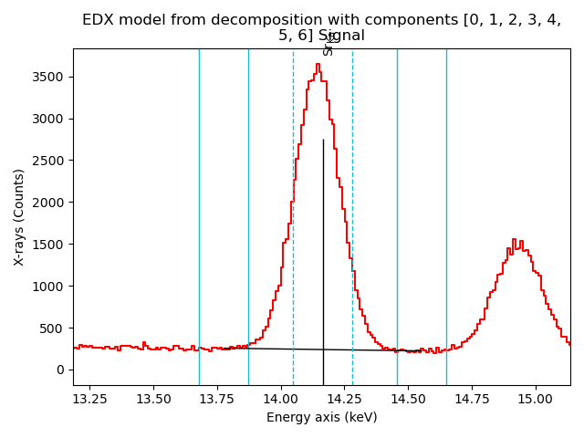

```python
s1 = s1.isig[bw_pos[0][0]-buffer:bw_pos[0][3]+buffer]
s1.plot(True, background_windows=bw_pos, integration_windows=iw_pos)
```

Optional: If x-ray line is shifted relative to peak position, we can perform a quick offset calibration for chosen x-ray line to center it.

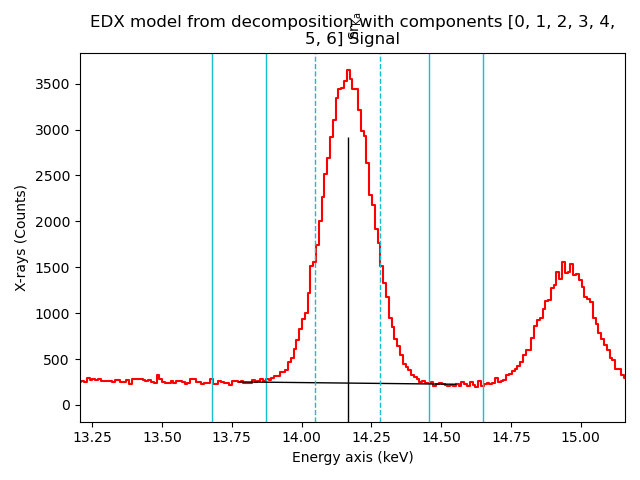

```python
sr = s1.isig[bw_pos[0][0]-buffer:bw_pos[0][3]+buffer]
m = sr.create_model(auto_background=False)
m.calibrate_energy_axis(calibrate='offset')
sr.plot(True, background_windows=bw_pos, integration_windows=iw_pos)
```

```python
# Overwrite s1 with calibrated sr
s1 = sr
```

Optional: Interactive placement of background windows.  
**Note:** Click on the plot first to select it, then click on the left or right background window and start dragging.

```
<EDSTEMSpectrum, title: EDX model from decomposition with components [0, 1, 2, 3, 4, 5, 6], dimensions: (|19)>
```

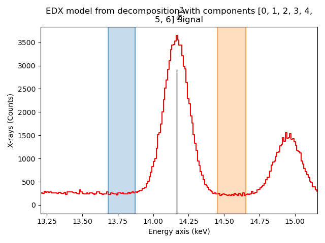

```python
# Initiate interactive ROI at current positions
roi_bwl = hs.roi.SpanROI(left=bw_pos[0][0], right=bw_pos[0][1])
roi_bwr = hs.roi.SpanROI(left=bw_pos[0][2], right=bw_pos[0][3])

# Interactive plot with ROI markers
s1.plot(xray_lines=True)
roi_bwl.interactive(s1, color='tab:blue')
roi_bwr.interactive(s1, color='tab:orange')
```

```python
bw_pos[0,:] = [roi_bwl.left, roi_bwl.right, roi_bwr.left, roi_bwr.right]
print('New background window positions:\n', xray_line, '\t', bw_pos[0])
```

```
New background window positions:
 Sr_Ka 	 [13.33106206 13.80167741 14.45572829 14.64954715]
```

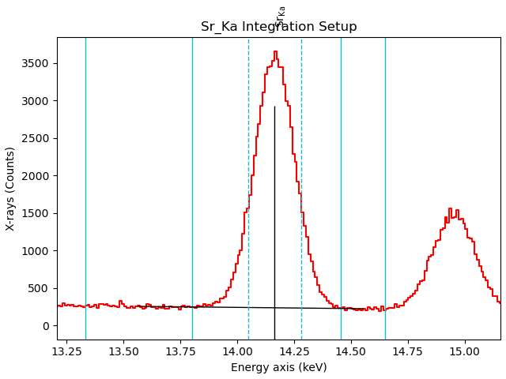

```python
s1.plot(True, background_windows=bw_pos, integration_windows=iw_pos)
fig, ax = plt.gcf(), plt.gca()
ax.set_title(f'{s1.metadata.Sample.xray_lines[0]} Integration Setup', fontsize='large')
fig.tight_layout(pad=0.5)
fig.savefig(info_path / (s1.metadata.Sample.xray_lines[0] + '.png'), dpi=300)
fig.savefig(info_path / (s1.metadata.Sample.xray_lines[0] + '.svg'))
```

Save the signal and window parameters for documentation:

```python
# Save signal
s1.save(info_path / (s1.metadata.Sample.xray_lines[0] + '.hspy'), overwrite=True)

# Save background/integration window parameters
f = open(info_path / (s1.metadata.Sample.xray_lines[0] + '_parameters.txt'), 'w')
f.write(f'# X-ray line: {s1.metadata.Sample.xray_lines[0]}\n')
f.write(f'# Background window position ({s1.axes_manager[-1].units}, rows 0-3) and Integration window position ({s1.axes_manager[-1].units}, rows 4-5)\n')
np.savetxt(f, bw_pos, delimiter='\n')
np.savetxt(f, np.array(iw_pos).reshape((2,)))
f.close()
```

Recall the signal and parameters from the saved files:

```python
#s2 = hs.load('HyperSpy_Analysis/Elemental_Maps/info/Y_Ka.hspy')
#bw_pos_loaded = np.loadtxt('HyperSpy_Analysis/Elemental_Maps/info/Y_Ka_parameters.txt', comments='#')[0:4].reshape((1,4))
#iw_pos_loaded = np.loadtxt('HyperSpy_Analysis/Elemental_Maps/info/Y_Ka_parameters.txt', comments='#')[4:].reshape((1,2)).tolist()
#s2.plot(True, background_windows=bw_pos_loaded, integration_windows=iw_pos_loaded)
```

```python
# Extract net intensities
eds_map = s.get_lines_intensity(background_windows=bw_pos, integration_windows=iw_pos)[0]

# Optional: Clip negative values to 0, can be commented out
eds_map.data[eds_map.data < 0] = 0

# Scale png image
upscale_factor = np.ceil(np.max(min_image_size_in_pixel/np.array(eds_map.data.shape)))
eds_map_scaled = rescale(eds_map.data, scale=upscale_factor, order=0)

# Save results
eds_map.save(hspy_path / (s1.metadata.Sample.xray_lines[0]+".hspy"), overwrite=True)
matplotlib.image.imsave(png_path / (s1.metadata.Sample.xray_lines[0]+".png"), eds_map.data, cmap='gray')
matplotlib.image.imsave(png_path / (s1.metadata.Sample.xray_lines[0]+"-scaled.png"), eds_map_scaled, cmap='gray')
save_scaled_tiff(eds_map, tiff_path / (s1.metadata.Sample.xray_lines[0]+".tif"))
```

### **Back to the start** to repeat for another x-ray line.

### **Option 2**: Single x-ray line - Load background/integration window positions from a file

Extract a single x-ray line intensity with window positions loaded from a `..._parameters.txt` file.

```python
# User Input
# Here we use the extracted Sr_Ka line as an example
xray_line = 'Sr_Ka'
```

```python
s.set_elements([]) # Clear present element list
s.set_lines([xray_line])
```

```python
window_params_file = info_path / (xray_line + '_parameters.txt')
```

Load parameters:

```python
bw_pos_loaded = np.loadtxt(window_params_file, comments='#')[0:4].reshape((1,4))
iw_pos_loaded = np.loadtxt(window_params_file, comments='#')[4:].reshape((1,2)).tolist()
```

Check background/integration window placement:

```python
# increase size of the energy window of interest by +- buffer (typically in keV)
buffer = 0.5
```

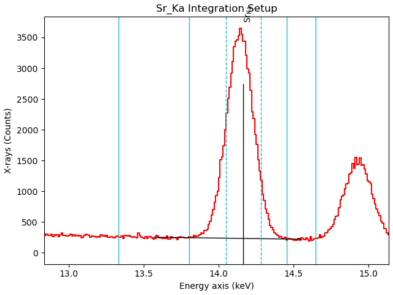

```python
s1 = s.sum().isig[bw_pos_loaded [0][0]-buffer:bw_pos_loaded[0][3]+buffer]
s1.plot(True, background_windows=bw_pos_loaded, integration_windows=iw_pos_loaded)

fig, ax = plt.gcf(), plt.gca()
ax.set_title(f'{s1.metadata.Sample.xray_lines[0]} Integration Setup', fontsize='large')
fig.tight_layout(pad=0.5)
fig.savefig(info_path / (s1.metadata.Sample.xray_lines[0] + '.png'), dpi=300)
fig.savefig(info_path / (s1.metadata.Sample.xray_lines[0] + '.svg'))
```

Save the signal and window parameters for documentation:

```python
# Save signal
s1.save(info_path / (s1.metadata.Sample.xray_lines[0] + '.hspy'), overwrite=True)
```

```python
# Extract net intensities
eds_map = s.get_lines_intensity(background_windows=bw_pos_loaded, integration_windows=iw_pos_loaded)[0]

# Optional: Clip negative values to 0, can be commented out
eds_map.data[eds_map.data < 0] = 0

# Scale png image
upscale_factor = np.ceil(np.max(min_image_size_in_pixel/np.array(eds_map.data.shape)))
eds_map_scaled = rescale(eds_map.data, scale=upscale_factor, order=0)

# Save results
eds_map.save(hspy_path / (s1.metadata.Sample.xray_lines[0]+".hspy"), overwrite=True)
matplotlib.image.imsave(png_path / (s1.metadata.Sample.xray_lines[0]+".png"), eds_map.data, cmap='gray')
matplotlib.image.imsave(png_path / (s1.metadata.Sample.xray_lines[0]+"-scaled.png"), eds_map_scaled, cmap='gray')
save_scaled_tiff(eds_map, tiff_path / (s1.metadata.Sample.xray_lines[0]+".tif"))
```

### **Back to the start** to repeat for another x-ray line.

### **Option 3**: Multiple x-ray lines

The same is done as in option 1 and 2.  
However, all background windows (and even integration window) positions are defined for each x-ray line before extracting the background-subtracted intensities.  
To start, we specify integration window width (iww) and X-ray lines of interest:

```python
# User input
iww = 1.2 # Default is 2.0(*FWHM)
xray_lines = ['Er_La', 'O_Ka', 'Y_Ka', 'Ba_La', 'Cu_Ka', 'Ti_Ka']
xray_lines = sorted(xray_lines)
```

```python
# Dont change anything here
s.set_elements([]) #Clear present element list
s.set_lines(xray_lines)

# Make a copy of the summed spectrum
s2 = s.sum().deepcopy()

bw_pos = s2.estimate_background_windows(line_width=[1.5, 1.5], windows_width=1.0)
iw_pos =  s2.estimate_integration_windows(windows_width=iww)
print('Background window positions:')
for i, line in enumerate(xray_lines):
    print(line, '\t', bw_pos[i])
```

```
Background window positions:
Ba_La 	 [4.17778007 4.29318804 4.68473505 4.80062509]
Cu_Ka 	 [7.67469856 7.82393913 8.27166087 8.42090144]
Er_La 	 [6.59927252 6.73900351 7.15819649 7.29792748]
O_Ka 	 [0.37772876 0.43659725 0.61320275 0.67207124]
Ti_Ka 	 [4.17778007 4.29318804 4.68473505 4.80062509]
Y_Ka 	 [14.46122517 14.6600951  15.2567049  15.45557483]
```

Check the sum spectrum and plot the background/integration windows. Leave the plot open to define the new positions if necessary.

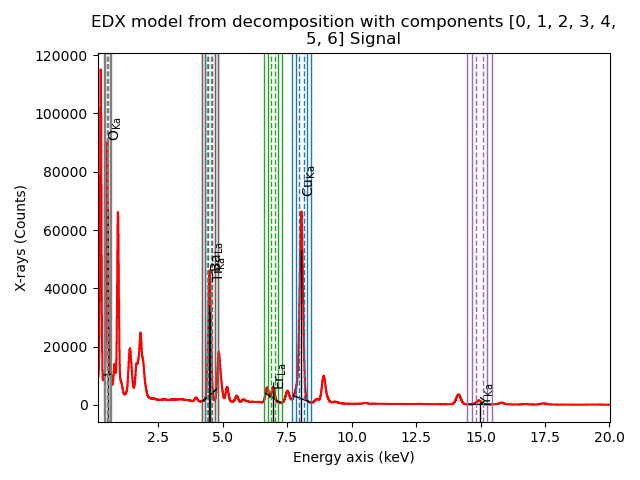

```python
s2.plot(True, background_windows=bw_pos, integration_windows=iw_pos)
```

Optional: If x-ray lines are shifted relative to peak position, we can perform a quick offset calibration using the chosen x-ray lines.

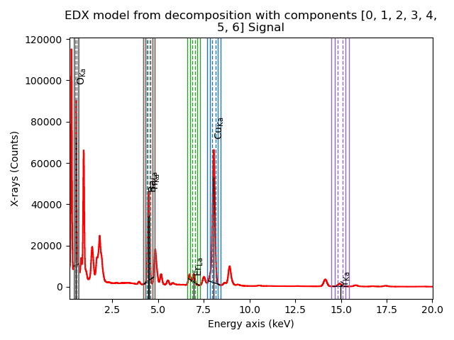

```python
sr = s2.deepcopy()
m = sr.create_model(auto_background=False)
m.calibrate_energy_axis(calibrate='offset', xray_lines='all_alpha')
m.calibrate_energy_axis(calibrate='scale', xray_lines='all_alpha')
sr.plot(True, background_windows=bw_pos, integration_windows=iw_pos)
```

```python
# Overwrite s2 with calibrated sr
s2 = sr
```

Optional: Interactive placement of background windows.  
An interactive plot will open for each x-ray transition. Drag the background windows to the desired positions.

```python
# increase size of the energy window of interest by +- buffer (typically in keV)
buffer = 1.0
```

```
Ba_La 	 [4.17778007 4.29318804 4.68473505 4.80062509]
Cu_Ka 	 [7.67469856 7.82393913 8.27166087 8.42090144]
Er_La 	 [6.59927252 6.73900351 7.15819649 7.29792748]
O_Ka 	 [0.37772876 0.43659725 0.61320275 0.67207124]
Ti_Ka 	 [4.17778007 4.29318804 4.68473505 4.80062509]
Y_Ka 	 [14.46122517 14.6600951  15.2567049  15.45557483]
```

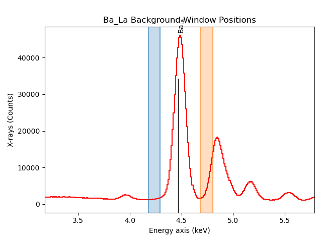

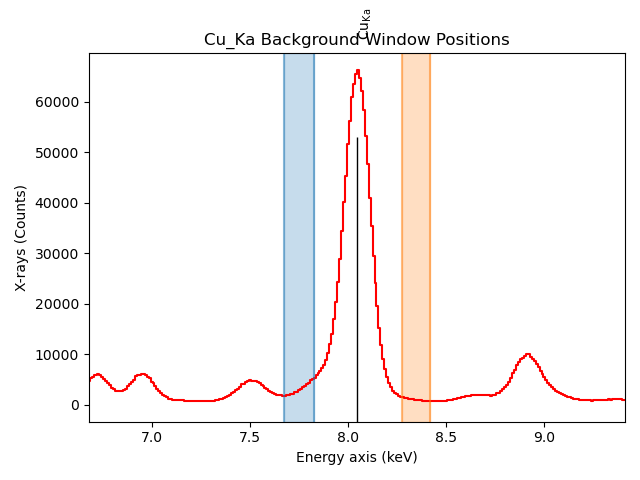

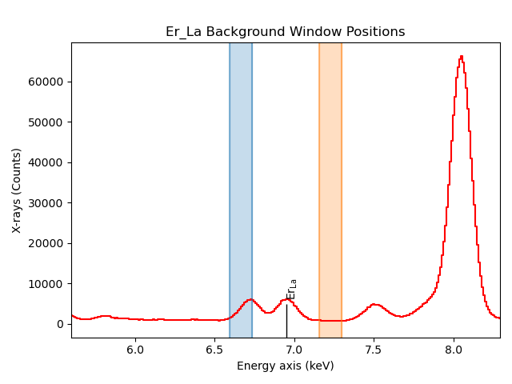

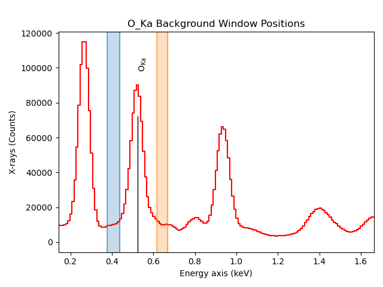

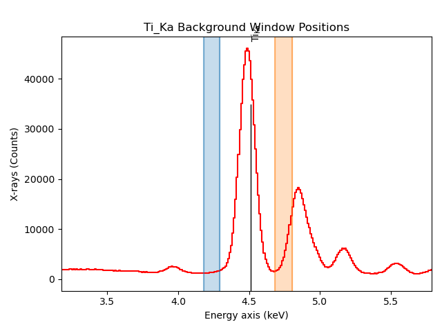

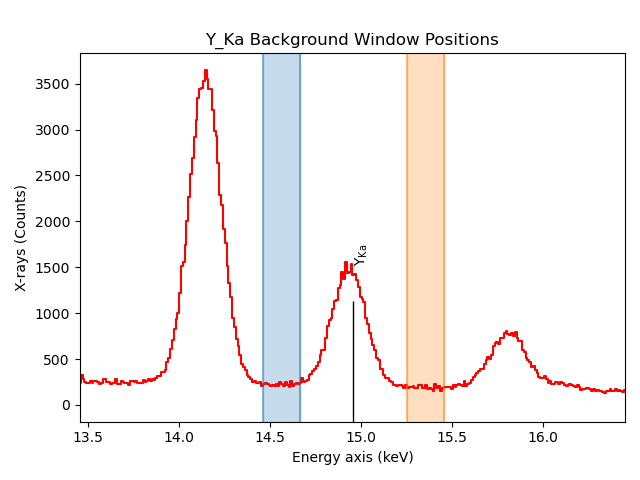

```python
roi_bwl = []
roi_bwr = []

for i, line in enumerate(sorted(xray_lines)):
    print(line, '\t', bw_pos[i])
    s_tmp = s2.isig[bw_pos[i][0]-buffer:bw_pos[i][3]+buffer]

    # Initiate updating ROI values
    roi_bwl.append((hs.roi.SpanROI(left=bw_pos[i][0], right=bw_pos[i][1])))
    roi_bwr.append((hs.roi.SpanROI(left=bw_pos[i][2], right=bw_pos[i][3])))

    # Interactive plot with ROI markers
    s_tmp.plot(xray_lines=[line])
    plt.gca().set_title(line + ' Background Window Positions', fontsize='large')
    roi_bwl[i].interactive(s_tmp, color='tab:blue')
    roi_bwr[i].interactive(s_tmp, color='tab:orange')
```

```python
print('New background window positions:')
for i, line in enumerate(xray_lines):
    bw_pos[i,:] = [roi_bwl[i].left, roi_bwl[i].right, roi_bwr[i].left, roi_bwr[i].right]
    print(line, '\t', bw_pos[i])
```

```
New background window positions:
Ba_La 	 [4.12159388 4.23171385 5.30288083 5.4230117 ]
Cu_Ka 	 [7.13487669 7.28504028 8.34619636 8.48634905]
Er_La 	 [6.0536988  6.51420049 7.16490941 7.3050621 ]
O_Ka 	 [0.34748218 0.40754762 1.17838741 1.24846375]
Ti_Ka 	 [4.12159388 4.26174657 5.31289173 5.43302261]
Y_Ka 	 [14.46122517 14.6600951  15.22368902 15.5140053 ]
```

Plot to check updated positions

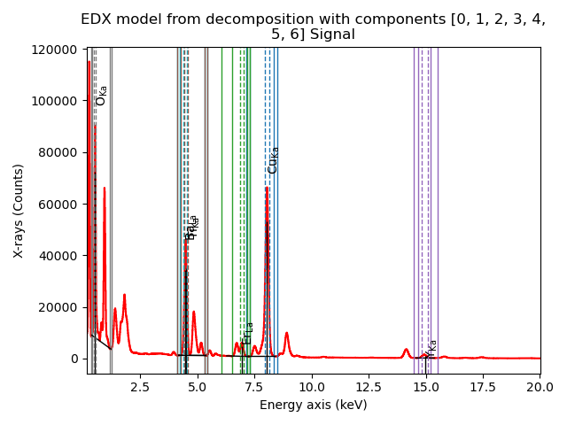

```python
s2.plot(True, background_windows=bw_pos, integration_windows=iw_pos)
```

```python
for i, line in enumerate(xray_lines):
    # Save window setup as an image
    s_tmp = s2.isig[bw_pos[i][0]-buffer:bw_pos[i][3]+buffer]
    s_tmp.plot(xray_lines=[line], background_windows=[bw_pos[i,:]], integration_windows=[iw_pos[i]])
    fig, ax = plt.gcf(), plt.gca()
    ax.set_title(f'{line} Integration Setup', fontsize='large')
    fig.tight_layout(pad=0.5)
    fig.savefig(info_path / (line + '.png'), dpi=300)
    fig.savefig(info_path / (line + '.svg'))
    plt.close()

    # Save signal
    s2.save(info_path / (line + '.hspy'), overwrite=True)

    # Save background/integration window parameters
    f = open(info_path / (line + '_parameters.txt'), 'w')
    f.write(f'# X-ray line: {line}\n')
    f.write(f'# Background window position ({s2.axes_manager[-1].units}, rows 0-3) and Integration window position ({s2.axes_manager[-1].units}, rows 4-5)\n')
    np.savetxt(f, bw_pos[i,:], delimiter='\n')
    np.savetxt(f, np.array(iw_pos[i]).reshape((2,)))
    f.close()
```

Extract integrated signals:

```python
eds_maps = s.get_lines_intensity(background_windows=bw_pos, integration_windows=iw_pos)
```

Save data:

```python
for i, map in enumerate(eds_maps):
    # Optional: Clip negative values to 0, can be commented out
    map.data[map.data < 0] = 0

    # Scale png image
    upscale_factor = np.ceil(np.max(min_image_size_in_pixel/np.array(map.data.shape)))
    map_scaled = rescale(map.data, scale=upscale_factor, order=0)

    # Save results
    map.save(hspy_path / (xray_lines[i]+".hspy"), overwrite=True)
    matplotlib.image.imsave(png_path / (xray_lines[i]+".png"), map.data, cmap='gray')
    matplotlib.image.imsave(png_path / (xray_lines[i]+"-scaled.png"), map_scaled, cmap='gray')
    save_scaled_tiff(map, tiff_path / (xray_lines[i]+".tif"))
```

Overview figure:

```
[<Axes: title={'center': 'Ba_La at 4.47 keV'}, xlabel='width axis (nm)', ylabel='height axis (nm)'>,
 <Axes: title={'center': 'Cu_Ka at 8.05 keV'}, xlabel='width axis (nm)', ylabel='height axis (nm)'>,
 <Axes: title={'center': 'Er_La at 6.95 keV'}, xlabel='width axis (nm)', ylabel='height axis (nm)'>,
 <Axes: title={'center': 'O_Ka at 0.52 keV'}, xlabel='width axis (nm)', ylabel='height axis (nm)'>,
 <Axes: title={'center': 'Ti_Ka at 4.51 keV'}, xlabel='width axis (nm)', ylabel='height axis (nm)'>,
 <Axes: title={'center': 'Y_Ka at 14.96 keV'}, xlabel='width axis (nm)', ylabel='height axis (nm)'>]
```

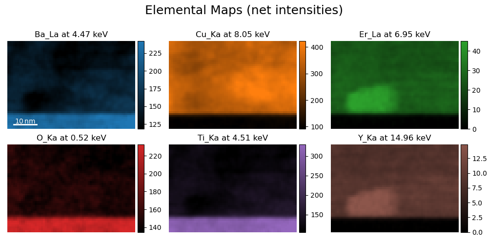

```python
#-------------------------
# Plotting options:
figtitle = 'Elemental Maps (net intensities)'
figsize = (10,5)
contrast_percentile = 1.0

#-------------------------
fig = plt.figure(figsize=figsize)

hs.plot.plot_images(eds_maps,
    tight_layout=True, cmap='mpl_colors', axes_decor='off',
    colorbar='multi', scalebar=[0], vmin=(str(contrast_percentile)+'th'), vmax=(str(100-contrast_percentile)+'th'),
    scalebar_color='white', suptitle=figtitle, fig=fig)
```

```python
fig.tight_layout(pad=0.3)
```

Save overview:

```python
fig.savefig(maps_path / "ElementalMaps_Overview.png", dpi=600)
fig.savefig(maps_path / "ElementalMaps_Overview.svg")
```

### **Option 4**: Multiple x-ray lines - Load background/integration window positions from a file

All background windows (and even integration window) positions are defined for muliplte x-ray lines are loaded from `_parameters.txt` files.  
Useful for processing of multiple SIs with the same elements.

```python
# User input
iww = 1.2 # Default is 2.0(*FWHM)
xray_lines = ['Er_La', 'O_Ka', 'Y_Ka', 'Ba_La', 'Cu_Ka', 'Ti_Ka']
xray_lines = sorted(xray_lines)
```

```python
# Create file paths
window_params_files = [info_path / (xray_line + '_parameters.txt') for xray_line in xray_lines]
```

```python
window_params_files
```

```
[PosixPath('/home/lukas/Documents/GitHub/eds-processing-notebooks/notebooks/data_processing_explained/HyperSpy_Analysis/Elemental_Maps/info/Ba_La_parameters.txt'),
 PosixPath('/home/lukas/Documents/GitHub/eds-processing-notebooks/notebooks/data_processing_explained/HyperSpy_Analysis/Elemental_Maps/info/Cu_Ka_parameters.txt'),
 PosixPath('/home/lukas/Documents/GitHub/eds-processing-notebooks/notebooks/data_processing_explained/HyperSpy_Analysis/Elemental_Maps/info/Er_La_parameters.txt'),
 PosixPath('/home/lukas/Documents/GitHub/eds-processing-notebooks/notebooks/data_processing_explained/HyperSpy_Analysis/Elemental_Maps/info/O_Ka_parameters.txt'),
 PosixPath('/home/lukas/Documents/GitHub/eds-processing-notebooks/notebooks/data_processing_explained/HyperSpy_Analysis/Elemental_Maps/info/Ti_Ka_parameters.txt'),
 PosixPath('/home/lukas/Documents/GitHub/eds-processing-notebooks/notebooks/data_processing_explained/HyperSpy_Analysis/Elemental_Maps/info/Y_Ka_parameters.txt')]
```

Load parameters:  
**Note:** The `parameters.txt` files for each x-ray line must be present in the `info` folder. Typically copied from the `info` folder from another SI analysis from the same sample with the same elements.

```python
bw_pos_loaded = [np.loadtxt(wpf, comments='#')[0:4].reshape((1,4)) for wpf in window_params_files]
bw_pos_loaded = np.array(bw_pos_loaded).reshape(6,4)
iw_pos_loaded = [np.loadtxt(wpf, comments='#')[4:].reshape((1,2)).tolist() for wpf in window_params_files]
iw_pos_loaded = sum(iw_pos_loaded, [])
```

Check the loaded background/integration window placement. Move/resize the windows interactively if changes are needed.

```python
# increase size of the energy window of interest by +- buffer (typically in keV)
buffer = 1.0
```

```
Ba_La 	 [4.12159388 4.23171385 5.30288083 5.4230117 ]
Cu_Ka 	 [7.13487669 7.28504028 8.34619636 8.48634905]
Er_La 	 [6.0536988  6.51420049 7.16490941 7.3050621 ]
O_Ka 	 [0.34748218 0.40754762 1.17838741 1.24846375]
Ti_Ka 	 [4.12159388 4.26174657 5.31289173 5.43302261]
Y_Ka 	 [14.46122517 14.6600951  15.22368902 15.5140053 ]
```

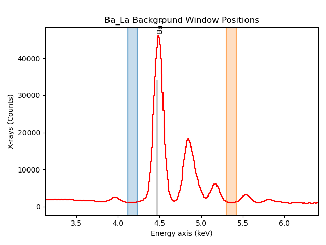

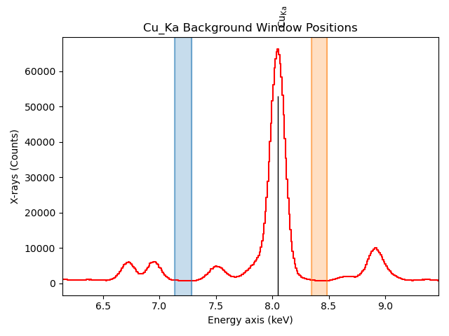

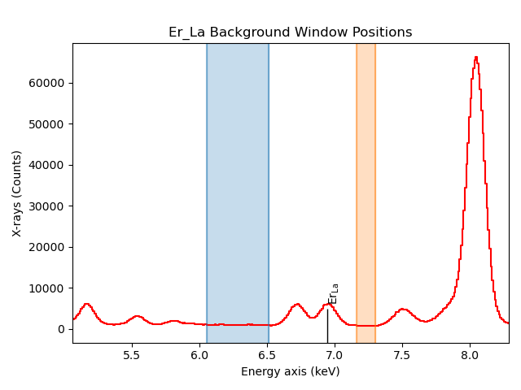

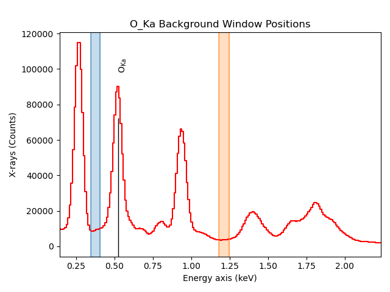

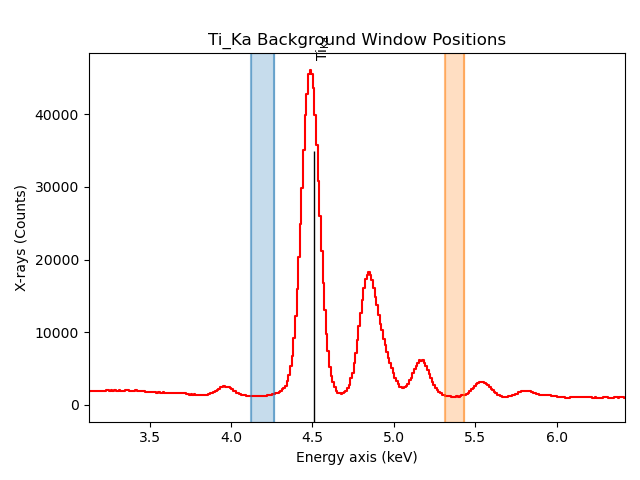

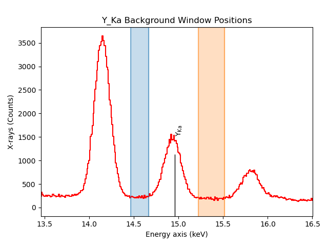

```python
roi_bwl = []
roi_bwr = []

for i, line in enumerate(sorted(xray_lines)):
    print(line, '\t', bw_pos_loaded[i])
    s_tmp = s2.isig[bw_pos_loaded[i][0]-buffer:bw_pos_loaded[i][3]+buffer]

    # Initiate updating ROI values
    roi_bwl.append((hs.roi.SpanROI(left=bw_pos_loaded[i][0], right=bw_pos_loaded[i][1])))
    roi_bwr.append((hs.roi.SpanROI(left=bw_pos_loaded[i][2], right=bw_pos_loaded[i][3])))

    # Interactive plot with ROI markers
    s_tmp.plot(xray_lines=[line])
    plt.gca().set_title(line + ' Background Window Positions', fontsize='large')
    roi_bwl[i].interactive(s_tmp, color='tab:blue')
    roi_bwr[i].interactive(s_tmp, color='tab:orange')
```

```python
print('New background window positions:')
for i, line in enumerate(xray_lines):
    bw_pos[i,:] = [roi_bwl[i].left, roi_bwl[i].right, roi_bwr[i].left, roi_bwr[i].right]
    print(line, '\t', bw_pos[i])
```

```
New background window positions:
Ba_La 	 [4.12159388 4.23171385 5.30288083 5.4230117 ]
Cu_Ka 	 [7.13487669 7.28504028 8.34619636 8.48634905]
Er_La 	 [6.0536988  6.51420049 7.16490941 7.3050621 ]
O_Ka 	 [0.34748218 0.40754762 1.17838741 1.24846375]
Ti_Ka 	 [4.12159388 4.26174657 5.31289173 5.43302261]
Y_Ka 	 [14.46122517 14.6600951  15.22368902 15.5140053 ]
```

Plot to check updated positions

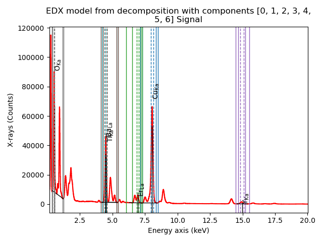

```python
# Make a copy of the summed spectrum
s4 = s.sum().deepcopy()
s4.plot(True, background_windows=bw_pos, integration_windows=iw_pos_loaded)
```

Save extraction parameters and window setup:

```python
for i, line in enumerate(xray_lines):
    # Save window setup as an image
    s_tmp = s4.isig[bw_pos[i][0]-buffer:bw_pos[i][3]+buffer]
    s_tmp.plot(xray_lines=[line], background_windows=[bw_pos[i,:]], integration_windows=[iw_pos_loaded[i]])
    fig, ax = plt.gcf(), plt.gca()
    ax.set_title(f'{line} Integration Setup', fontsize='large')
    fig.tight_layout(pad=0.5)
    fig.savefig(info_path / (line + '.png'), dpi=300)
    fig.savefig(info_path / (line + '.svg'))
    plt.close()

    # Save signal
    s4.save(info_path / (line + '.hspy'), overwrite=True)

    # Save background/integration window parameters
    f = open(info_path / (line + '_parameters.txt'), 'w')
    f.write(f'# X-ray line: {line}\n')
    f.write(f'# Background window position ({s4.axes_manager[-1].units}, rows 0-3) and Integration window position ({s4.axes_manager[-1].units}, rows 4-5)\n')
    np.savetxt(f, bw_pos[i,:], delimiter='\n')
    np.savetxt(f, np.array(iw_pos[i]).reshape((2,)))
    f.close()
```

Extract integrated signals:

```python
eds_maps = s.get_lines_intensity(background_windows=bw_pos, integration_windows=iw_pos_loaded)
```

Save data:

```python
for i, map in enumerate(eds_maps):
    # Optional: Clip negative values to 0, can be commented out
    map.data[map.data < 0] = 0

    # Scale png image
    upscale_factor = np.ceil(np.max(min_image_size_in_pixel/np.array(map.data.shape)))
    map_scaled = rescale(map.data, scale=upscale_factor, order=0)

    # Save results
    map.save(hspy_path / (xray_lines[i]+".hspy"), overwrite=True)
    matplotlib.image.imsave(png_path / (xray_lines[i]+".png"), map.data, cmap='gray')
    matplotlib.image.imsave(png_path / (xray_lines[i]+"-scaled.png"), map_scaled, cmap='gray')
    save_scaled_tiff(map, tiff_path / (xray_lines[i]+".tif"))
```

Overview figure:

```
[<Axes: title={'center': 'Ba_La at 4.47 keV'}, xlabel='width axis (nm)', ylabel='height axis (nm)'>,
 <Axes: title={'center': 'Cu_Ka at 8.05 keV'}, xlabel='width axis (nm)', ylabel='height axis (nm)'>,
 <Axes: title={'center': 'Er_La at 6.95 keV'}, xlabel='width axis (nm)', ylabel='height axis (nm)'>,
 <Axes: title={'center': 'O_Ka at 0.52 keV'}, xlabel='width axis (nm)', ylabel='height axis (nm)'>,
 <Axes: title={'center': 'Ti_Ka at 4.51 keV'}, xlabel='width axis (nm)', ylabel='height axis (nm)'>,
 <Axes: title={'center': 'Y_Ka at 14.96 keV'}, xlabel='width axis (nm)', ylabel='height axis (nm)'>]
```

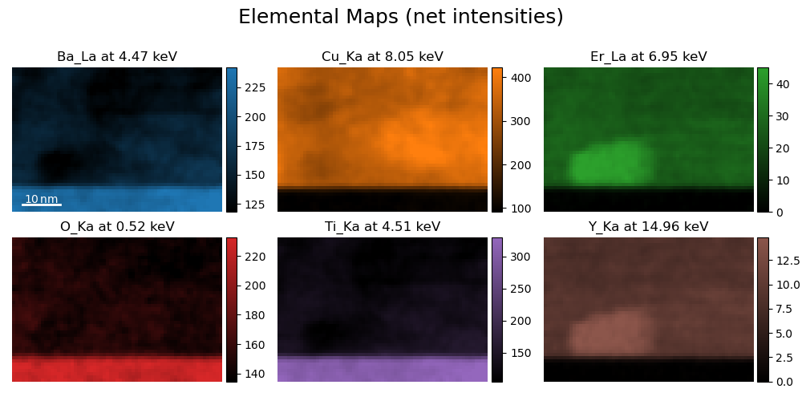

```python
#-------------------------
# Plotting options:
figtitle = 'Elemental Maps (net intensities)'
figsize = (10,5)
contrast_percentile = 1.0

#-------------------------
fig = plt.figure(figsize=figsize)

hs.plot.plot_images(eds_maps,
    tight_layout=True, cmap='mpl_colors', axes_decor='off',
    colorbar='multi', scalebar=[0], vmin=(str(contrast_percentile)+'th'), vmax=(str(100-contrast_percentile)+'th'),
    scalebar_color='white', suptitle=figtitle, fig=fig)
```

```python
fig.tight_layout(pad=0.3)
```

Save overview:

```python
fig.savefig(maps_path / "ElementalMaps_Overview.png", dpi=600)
fig.savefig(maps_path / "ElementalMaps_Overview.svg")
```

## **Option 5**: Fit Gaussians to seperate overlapping lines

In case of x-ray peak overlap, we can try to fit Gaussians to model the x-ray lines (actually, the whole x-ray line family).  
Here, we use it to separate the **overlapping Ba L$\alpha$ and Ti K$\alpha$ lines** as an example.

The procedure is as follows:

1. Crop the energy dimension to the peak-overlap region (the less Gaussian to fit, the faster). You may include a few surrounding peaks if there is possible overlap with multiple lines (especially at energies < 5 keV).
2. Add possible elements of the sample and signals from spurious x-rays from the microscope hardware, contamination. Based on the energy intervall, HyperSpy will add only the relevant x-ray transitions in the selected energy interval.
3. Initialize a HyperSpy model. Relevant x-ray lines in the energy region will be added automatically as Gaussian functions with fixed position and width.
4. Optional: Re-calibrate energy axis if peak positions or peak widths appear wrong.
5. Add a background function to the model: For TEM, a linear funtion (polynomial of 1st order) is OK. For SEM you may want to try the default 6th order polynomial.
6. Specifiy some optional model parameters: Add extra X-ray lines, change fitting bounds, ...
7. Fit the model at a specific location, e.g. at position (0,0), to initialize some sensible starting parameters.
8. Run `multifit` to fit at each pixel. This may take a while.

We make a copy of the PCA_filtered datacube and work with that:

```python
s_fit = s.deepcopy()
```

Inspect and crop signal to overlap region:

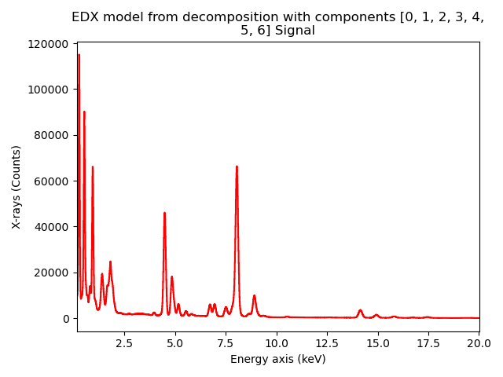

```python
s_fit.sum().plot()
```

```python
# Crop energy to peak-overlap region
s_fit = s_fit.isig[3.7:6.3] # Must be float to be recongnized as keV, e.g. use "1.0"" instead of "1"

# Interactive method
#s_fit.crop_signal1D()
```

#### Set up x-ray lines and fit function:

The `beam_energy` is set up at the higher limit of the (cropped) energy range. Hyperspy adds only x-ray lines up to this energy.

```python
s_fit.set_elements([]) # erase present element list
s_fit.set_microscope_parameters(beam_energy = s_fit.axes_manager[-1].high_value) # get highest energy of cropped signal
```

Adjust the `add_elements` function: add **all** possibly detectable elements and also spurious signal from the microscope materials.  
HyperSpy will only add the relevant x-ray lines in the cropped energy window to the model.

```python
s_fit.add_elements(['Au', 'Ba', 'Cu', 'Er', 'F', 'Gd', 'Hf', 'Ho', 'O', 'Sr', 'Ti', 'Y']) # sample x-rays
s_fit.add_elements(['Al', 'C', 'Cu', 'Si', 'Ni', 'Pt', 'Zn', 'Zr']) # artifacts & spurious signal of microscope/grid/contamination...
```

Initialize the model:

```python
m = s_fit.create_model(auto_background=False)
```

Add a background function:  
Here we use a simple linear fit. This works often for modeling the bremsstrahlung background for energies > 1 keV. Below you may want to try other background models.

```python
m.add_polynomial_background(order=1)
```

Optional: Limit linear background to only fit negativ slopes to model TEM EDS background. This is valid for most energy windows > 1 keV in TEM EDS. In the low energy region combine with small energy ROI the background may have a rising slope (then change to `bmin = 0`).

```python
m.background_components[0].a1.bmax = 0 # Set maximum value of slope to 0
```

Optional: Calibrate the energy axis for the model:

```python
print('FWHM Before (keV): ', s_fit.metadata.Acquisition_instrument.TEM.Detector.EDS.energy_resolution_MnKa)
m.calibrate_energy_axis(calibrate='resolution')
m.calibrate_energy_axis(calibrate='offset')
m.calibrate_energy_axis(calibrate='scale')
print('FWHM After (keV): ', s_fit.metadata.Acquisition_instrument.TEM.Detector.EDS.energy_resolution_MnKa)
```

```
FWHM Before (keV):  130.0
FWHM After (keV):  129.72580456938155
```

Print all functions/parameters of the model, check here if all x-ray lines of interest are present:

```python
np.shape(m) # number of components
```

```
(15,)
```

```python
m.print_current_values(fancy=False)
```

```
EDSTEMModel: EDX model from decomposition with components [0, 1, 2, 3, 4, 5, 6]
current_component_values: Ba_La
Active: True
Parameter Name |    Free |      Value |        Std |        Min |        Max | Linear
============== | ======= | ========== | ========== | ========== | ========== | ======
             A |    True | 155.355467 | 0.73274139 |        0.0 |       None |   True
        centre |   False |     4.4663 | 0.00028121 |       None |       None |  False
         sigma |   False | 0.04887805 | 0.00020233 |       None |       None |  False

current_component_values: Ba_Lb1
Active: True
Parameter Name |    Free |      Value |        Std |        Min |        Max | Linear
============== | ======= | ========== | ========== | ========== | ========== | ======
             A | Twinned | 66.8774217 |       None |        0.0 |       None |   True
        centre |   False |     4.8275 |       None |       None |       None |  False
         sigma |   False | 0.05051641 |       None |        0.0 |       None |  False

current_component_values: Ba_Lb2
Active: True
Parameter Name |    Free |      Value |        Std |        Min |        Max | Linear
============== | ======= | ========== | ========== | ========== | ========== | ======
             A | Twinned | 29.5952166 |       None |        0.0 |       None |   True
        centre |   False |     5.1571 |       None |       None |       None |  False
         sigma |   False | 0.05196639 |       None |        0.0 |       None |  False

current_component_values: Ba_Lb4
Active: True
Parameter Name |    Free |      Value |        Std |        Min |        Max | Linear
============== | ======= | ========== | ========== | ========== | ========== | ======
             A | Twinned | 13.7629408 |       None |        0.0 |       None |   True
        centre |   False |     4.8521 |       None |       None |       None |  False
         sigma |   False | 0.05062607 |       None |        0.0 |       None |  False

current_component_values: Ba_Ln
Active: True
Parameter Name |    Free |      Value |        Std |        Min |        Max | Linear
============== | ======= | ========== | ========== | ========== | ========== | ======
             A | Twinned | 2.34586756 |       None |        0.0 |       None |   True
        centre |   False |     4.3308 |       None |       None |       None |  False
         sigma |   False | 0.04824909 |       None |        0.0 |       None |  False
```

[output cut: 64 more lines]

```

current_component_values: Ti_Kb
Active: True
Parameter Name |    Free |      Value |        Std |        Min |        Max | Linear
============== | ======= | ========== | ========== | ========== | ========== | ======
             A | Twinned | 1.26446756 |       None |        0.0 |       None |   True
        centre |   False |     4.9318 |       None |       None |       None |  False
         sigma |   False | 0.05097971 |       None |        0.0 |       None |  False

current_component_values: background_order_1
Active: True
Parameter Name |    Free |      Value |        Std |        Min |        Max | Linear
============== | ======= | ========== | ========== | ========== | ========== | ======
            a0 |    True | 60.9259289 | 4.72511231 |       None |       None |   True
            a1 |    True | -4.1455492 | 0.94479903 |       None |        0.0 |   True
```

#### Setting up the model fit

We check the fitted model at specific locactions in the SI to see if the fit works well or not (e.g., if we missed a (spurious) element).

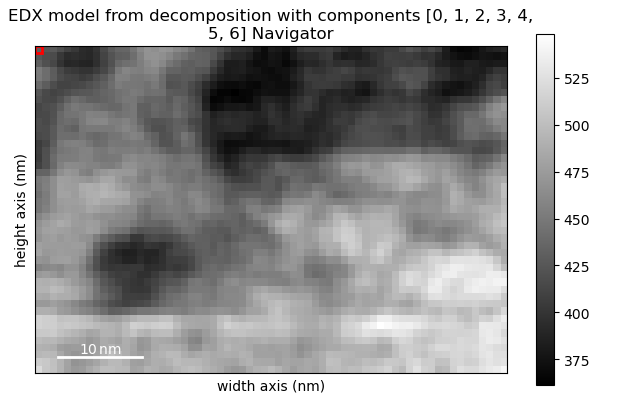

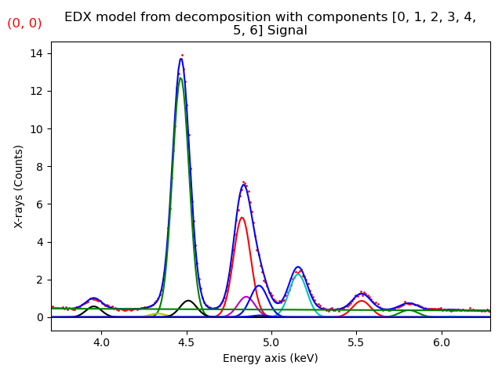

```python
#Plot the SI and the current fit
m.plot(True)
```

We can navigate the positions using the arrow keys or mouse.  
Alternatively, use this command to move to a position `(40,20)` or any other position to test your fit model (alternative to cursor in plot window):

```python
m.axes_manager.indices = (40, 20) #x, y coordinates
```

Run the fit at current position (this will update the previous plot):

```python
m.fit(bounded=True, return_info=False)
```

The fit **should** look relatively good now.  
If you see large discrepancies, check again for possible missing elements and/or a miscalibrated energy scale (if peaks seem to be at a wrong position).  
Check `m.fit` for different phases/positions in your SI to make sure fit works everywhere.

After fitting at a single representative position, we assign the starting parameters of fitted position to *all* pixels in the SI to speed up fitting:

```python
#Assign starting parameters of fitted position to all pixels in SI
m.assign_current_values_to_all()
```

Approximate duration of the multifit on the SI.  
For qt backend: Close window with fitted curve, it will skew duration estimation since it updates for every fit.

```python
# For qt backend, we close all open windows
#plt.close('all')
```

```python
def approx_multifit_duration(model, n_inav = 20):
    fit_timings = []
    for i in range(n_inav):
        p0 = np.round(np.random.random()*model.axes_manager.navigation_shape[0])
        p1 = np.round(np.random.random()*model.axes_manager.navigation_shape[1])
        model.axes_manager.indices = (p0, p1)
        t = %timeit -r 1 -n 1 -o -q model.fit(bounded=True, return_info=False)
        fit_timings.append(t.timings[0])
    tot_duration = np.average(fit_timings)*model.axes_manager.navigation_shape[0]*model.axes_manager.navigation_shape[1] #in seconds
    print(f'Fit on a single position takes approximately {np.round(np.average(fit_timings)*1e3, 3)} ms. (Average of {n_inav} positions)')
    print(f'Multifit of {model.axes_manager.navigation_shape[0]}*{model.axes_manager.navigation_shape[1]}={model.axes_manager.navigation_shape[0]*model.axes_manager.navigation_shape[1]} pixels will take approximately {np.round(tot_duration)} s (or {np.round(tot_duration/60, 2)} min, {np.round(tot_duration/3600, 2)} h)')
```

```python
approx_multifit_duration(m)
```

```
Fit on a single position takes approximately 74.935 ms. (Average of 20 positions)
Multifit of 65*45=2925 pixels will take approximately 219.0 s (or 3.65 min, 0.06 h)
```

#### Perform multifit on the whole SI (might take a while):

```python
%%timeit -r 1 -n 1
m.multifit(optimizer="lm",
           bounded=True,
           iterpath="serpentine",
           show_progressbar=True)
```

```
50.8 s ± 0 ns per loop (mean ± std. dev. of 1 run, 1 loop each)
```

We can inspect the fitted spectra by plotting the model.  
Note how the Ba L$\alpha$ and Ti K$\alpha$ amplitudes change from the Ba-containing REBCO film (upper) to Ti-containing STO subtrate (lower).

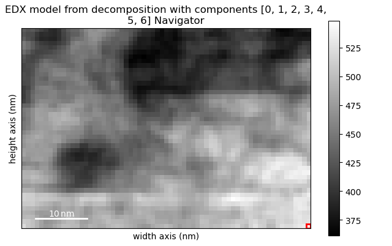

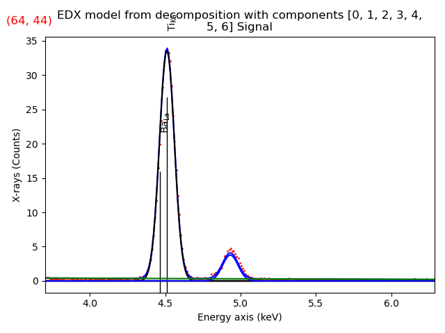

```python
m.plot(True, xray_lines=['Ba_La', 'Ti_Ka'])
```

#### Extract intensities from model

Note: X-ray lines don't have to be ordered alphabetically. This will be done by the `sorted` function.

```python
# User input
xray_lines = ['Ba_La', 'Ti_Ka']
xray_lines = sorted(xray_lines)
```

```python
s_fit.set_elements([])  # Clear present element list
s_fit.set_lines(xray_lines) # Set x-ray lines

mI = m.get_lines_intensity(xray_lines) #Get the A parameter, i.e. amplitude of the Gaussians of interest
```

Save the elemental maps.  
The filenames have an added `-fit` to indicate is was extracted by model fitting.

```python
for i, map in enumerate(mI):
    # Scale png image
    upscale_factor = np.ceil(np.max(min_image_size_in_pixel/np.array(map.data.shape)))
    map_scaled = rescale(map.data, scale=upscale_factor, order=0)

    # Save results
    map.save(hspy_path / (xray_lines[i]+"-fit.hspy"), overwrite=True)
    matplotlib.image.imsave(png_path / (xray_lines[i]+"-fit.png"), map.data, cmap='gray')
    matplotlib.image.imsave(png_path / (xray_lines[i]+"-fit-scaled.png"), map_scaled, cmap='gray')
    save_scaled_tiff(map, tiff_path / (xray_lines[i]+"-fit.tif"))
```

Overview plot:

```
[<Axes: title={'center': 'Ba_La (fit)'}, xlabel='width axis (nm)', ylabel='height axis (nm)'>,
 <Axes: title={'center': 'Ti_Ka (fit)'}, xlabel='width axis (nm)', ylabel='height axis (nm)'>]
```

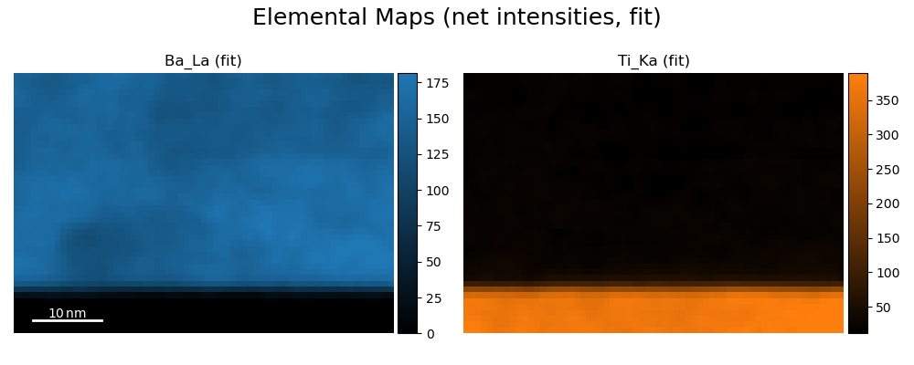

```python
#-------------------------
# Plotting options:
figtitle = 'Elemental Maps (net intensities, fit)'
figsize = (10, 4) #inches
contrast_percentile = 1.0
labels = ['Ba_La (fit)', 'Ti_Ka (fit)']

#-------------------------
fig = plt.figure(figsize=figsize)
hs.plot.plot_images(mI,
    tight_layout=True, cmap='mpl_colors', axes_decor='off', label=labels,
    colorbar='multi', scalebar=[0], vmin=(str(contrast_percentile)+'th'), vmax=(str(100-contrast_percentile)+'th'),
    scalebar_color='white', suptitle=figtitle, fig=fig)
```

Save the fitted model. Especially useful if the fitting took a long time.

```python
model_path = maps_path / 'models'
create_folder(model_path)
```

```
Successfully created the directory /home/lukas/Documents/GitHub/eds-processing-notebooks/notebooks/data_processing_explained/HyperSpy_Analysis/Elemental_Maps/models
```

```python
modelname = 'Model_BaLa-TiKa-Overlap'
m.save(model_path / (modelname+".hspy"))
```

Optional: This how to load a saved model:

```python
#Load model
#ml = hs.load(model_path / (modelname+".hspy"))
#m = ml.models.restore('a')
#m.plot(True) #Inspect fit
```

### **Back to the start** to repeat model fitting for other energy regions/peak overlaps.